# NSW Road Crash Severity Prediction

21 May 2026

## Research Question & Motivation

**Research Question:**

> Given environmental conditions (weather, lighting, road surface, speed limit) and traffic unit characteristics (TU type, manoeuvre, number of units), can we predict NSW road crash severity **(Fatal / Injury / Non-casualty)**? A three-class classification problem.

**Why this matters:**

- NSW recorded **340 road fatalities in 2024**; over two-thirds in regional areas *(TfNSW, 2025)*
- Fatal crashes are only **~1.4%** of all records - a severe class imbalance that naive models simply ignore
- Environmental and traffic conditions are knowable *at the time of the crash*, making real-time prediction feasible
- A robust model provides actionable intelligence across multiple decision-making contexts

**Stakeholder value:**

| Stakeholder | Application |
| --- | --- |
| **Traffic Authorities** | Target speed limits and road design in high-risk corridors |
| **Emergency Responders** | Dispatch resources proportional to predicted severity before on-scene confirmation |
| **Policymakers & Insurers** | Evidence-based road safety policy and risk-adjusted pricing |

The core challenge: **Fatal crashes are rare** (~1.4%) but highest-consequence. Standard accuracy metrics fail here - we need models and evaluation that explicitly prioritise the minority class.

## EDA & Data Understanding: Dataset Overview

| Item | Detail |
| --- | --- |
| Time Period | 2020 - 2024 |
| Data Sources | CRASH.xlsx + TRAFFIC UNIT.xlsx (TfNSW via data.gov.au) |
| Merge Key | Crash ID (left join) |
| Total Records | 170,962 |
| Total Variables | 59 |
| Target Variable | Degree of Crash (3-class classification) |
| Fatal | 2,416 (1.4%) |
| Injury | 114,355 (66.9%) |
| Non-casualty | 54,191 (31.7%) |

The merged dataset combines crash-level environmental conditions with traffic unit vehicle data, giving us both **where** a crash happened and **who** was involved. 170,962 records spanning 5 years provide robust signal for modelling, but the extreme class imbalance (Fatal = 1.4%) demands careful handling throughout.

## EDA & Data Understanding: Class Imbalance

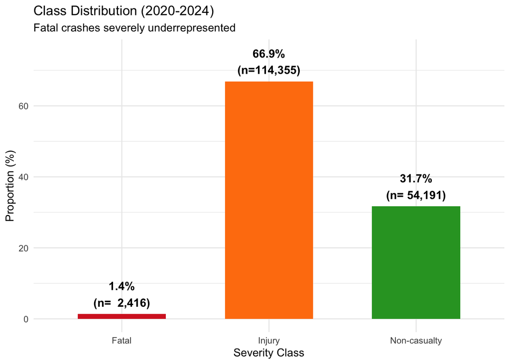

| Issue / Decision | Detail |
| --- | --- |
| **Class imbalance** | Fatal only ~1.4% of all crashes |
| **Risk of naive models** | Accuracy-maximising models ignore Fatal entirely |
| **Imbalance strategy** | Inverse-frequency class weights (all models) |
| **SMOTE** | Applied inside training fold only; synthetic Fatal share raised to ~10% in training |
| **Primary metrics** | Macro-F1 and Fatal Recall (target >= 0.50) |

## EDA & Data Understanding: Speed vs Severity

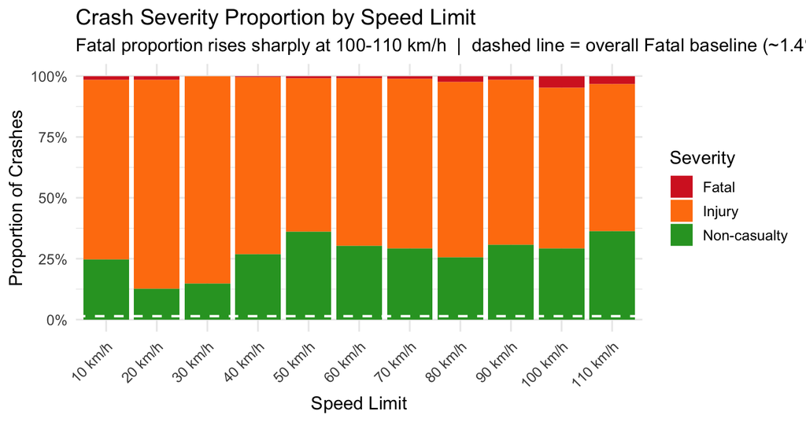

**50-60 km/h zones** dominate crash *volume* (urban traffic), but fatal *proportion* is low - volume and risk are decoupled.

**Motivates `speed_band`** feature: grouping ≤50 / 60-80 / 90-100 / 110 captures the non-linear jump in fatal risk.

## EDA & Data Understanding: High-Risk Scenarios

| Speed Limit | Lighting | Urbanisation | Total Crashes | Fatal % |
| --- | --- | --- | --- | --- |
| 110 km/h | Dusk | Country non-urban | 230 | 7.8% |
| 100 km/h | Darkness | Country non-urban | 2565 | 6.8% |
| 100 km/h | Dusk | Country non-urban | 626 | 6.7% |
| 100 km/h | Daylight | Country non-urban | 7490 | 5.5% |
| 110 km/h | Darkness | Country non-urban | 1215 | 5.4% |
| 80 km/h | Dawn | Country urban | 270 | 4.8% |
| 70 km/h | Darkness | Country urban | 463 | 4.8% |
| 80 km/h | Darkness | Country urban | 1536 | 4.7% |
| 110 km/h | Darkness | Sydney metro. area | 245 | 4.5% |
| 100 km/h | Dawn | Country non-urban | 455 | 4.2% |

**Feature validation:** All three risk dimensions - speed (`speed_band`), lighting (`is_night`), and location (`Urbanisation`) - are directly captured in our engineered feature set.

**Interaction matters:** 100 km/h + Daylight + Rural still yields 5.5% Fatal. Speed alone is not sufficient - the model needs to learn joint combinations.

## EDA & Data Understanding: Temporal Patterns

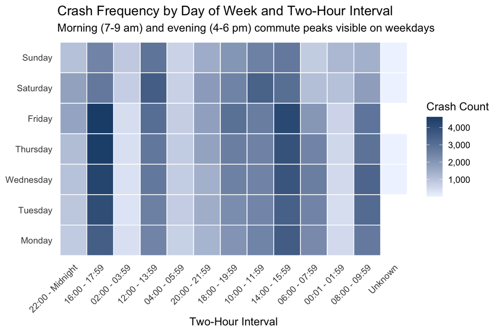

> **Key finding:** Volume peaks at weekday commute hours, motivating `is_rush_hour` and `is_weekend` features. Fatal *rate* (not count) is elevated on weekends and late-night hours.

## Data Preprocessing: Pipeline

**Steps 1-5: Cleaning & Feature Engineering**

1. **TU Integration** - aggregated traffic-unit flags per crash (`has_motorcycle`, `has_heavy_vehicle`, `has_pedestrian`, `has_cyclist`) using `group_by + summarise + left_join`
2. **Feature removal** - dropped leakage columns (post-crash injury counts), identifiers, and variables with >75% missing values; dropped `Degree of crash - detailed` (redundant with target)
3. **Imputation** - removed rows >50% missing; categorical : `"Unknown"`; numeric : median
4. **Feature engineering** - `is_weekend`, `is_rush_hour`, `is_night`, `is_wet`, speed bands - all motivated by EDA findings
5. **Outlier handling** - NSW geographic bounds filter; winsorise `Distance` at 99th percentile

**Steps 6-9: Modelling Setup**

6. **Encoding** - trees use native R `factor`; KNN/LR use one-hot; rare LGA levels : `"Other"`
7. **Scaling** - Z-score standardisation within fold for KNN; trees are scale-invariant
8. **Class imbalance** - inverse-frequency class weights (all models); SMOTE applied **inside training fold only**
9. **Split** - 2024 data sealed as temporal holdout; 80/20 stratified split on 2020-2023; 5-fold CV

## Data Preprocessing: Feature Engineering & Class Balancing

Engineered features - all motivated by EDA

[output not shown]

Handling class imbalance

| Issue | Strategy |
| --- | --- |
| Fatal only ~1.4% of crashes | Naive accuracy-maximising models predict majority class only - useless for our goal |
| Class weights (all models) | Inverse-frequency weights penalise Fatal misclassification more heavily during training |
| SMOTE (LR, KNN) | Synthetic oversampling applied inside training fold only; Fatal raised to ~10% - test set unmodified |
| Primary metrics | Macro-F1 (equal weight across classes) + Fatal Recall (hard constraint: target ≥ 0.50) |

## Model Fitting: Approach & Setup

We implemented six diverse classification models to balance interpretability and predictive power. All models were trained on the same stratified 50% subsample (\(n \approx 55,000\)) to ensure fair comparison.

| Model | R Package | Imbalance Strategy | Primary Hyperparameter |
| --- | --- | --- | --- |
| **Multinomial LR** | `nnet` | SMOTE (inside CV) | `decay` (L2 Penalty) |
| **Decision Tree** | `rpart` | Class Weights | `cp` (Complexity) |
| **Random Forest** | `randomForest` | Class Weights | `mtry` |
| **XGBoost** | `xgboost` | SMOTE / Weights | `nrounds`, `max_depth` |
| **KNN** | `kknn` | SMOTE (inside CV) | `k` (Neighbors) |
| **Naive Bayes** | `naive_bayes` | SMOTE (inside CV) | `laplace`, `usekernel` |

## Model Fitting: Logistic Regression

Logistic regression served as our **interpretable baseline** model. It helps show how key predictors are associated with crash severity, while also giving us a benchmark for comparing more flexible models.

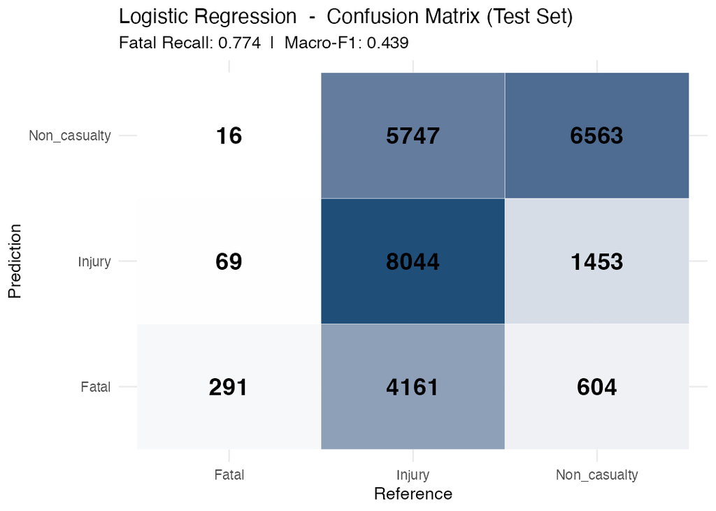

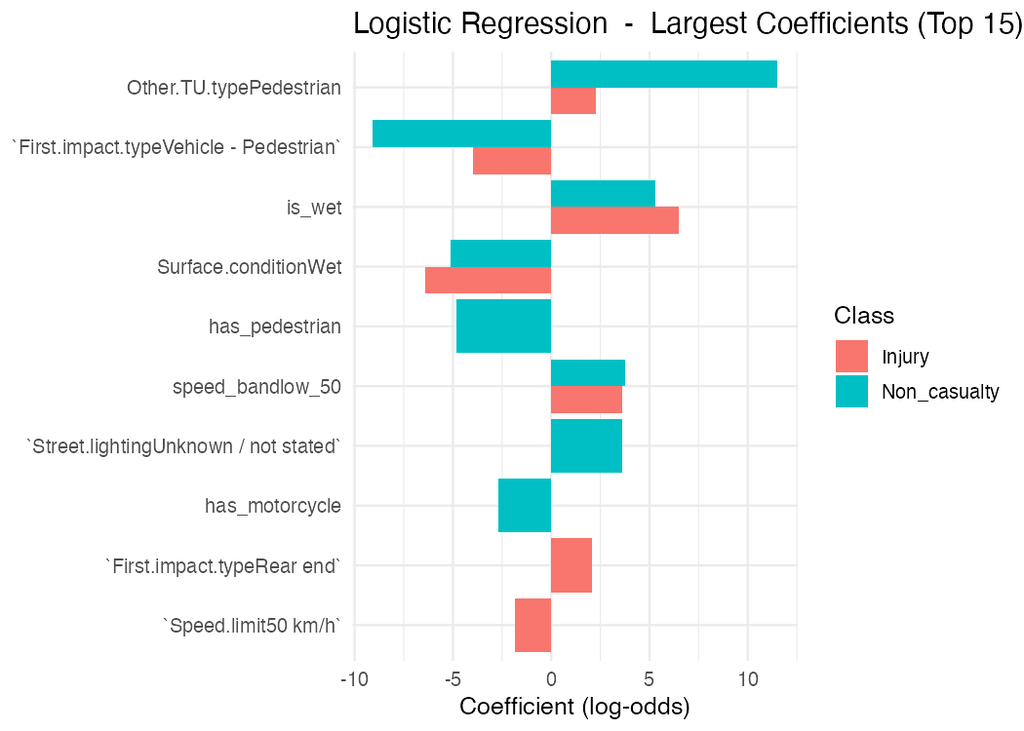

| Metric | Value |
| --- | --- |
| Macro-F1 | 0.4395 |
| **Fatal Recall** | **0.7739** |
| Weighted F1 | 0.5914 |
| Kappa | 0.2724 |

## Model Fitting: Decision Tree

Decision Tree was included because it produces clear **if-then style rules**, making it easier to explain the model to a non-technical audience. It reveals hierarchical relationships between risk factors.

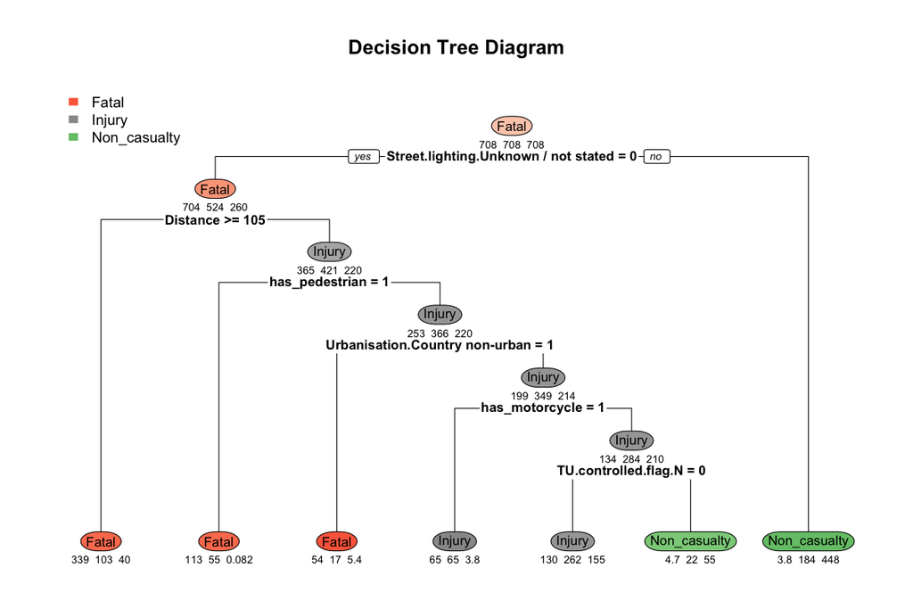

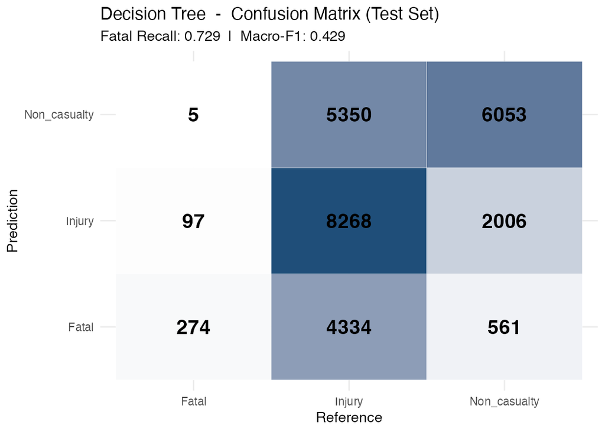

| Metric | Value |
| --- | --- |
| Macro-F1 | 0.4290 |
| **Fatal Recall** | **0.7287** |
| Weighted F1 | 0.5837 |
| Kappa | 0.2430 |

**Key message:** The tree identifies **Street Lighting** and **Distance** as the primary root splits. Using heavy class weights ensures the model actively searches for Fatal outcomes, satisfying safety constraints.

## Model Fitting: Random Forest

Random Forest was chosen as our **ensemble learner** - by averaging hundreds of decorrelated trees it reduces variance and handles the non-linear interactions between speed, location, and lighting that single trees miss. Built-in OOB error replaces CV, making it feasible on large data.

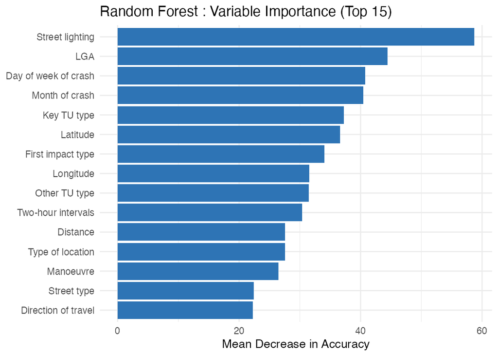

**Top predictors:** Street lighting, LGA, Day of week, Month - environmental context dominates vehicle type.

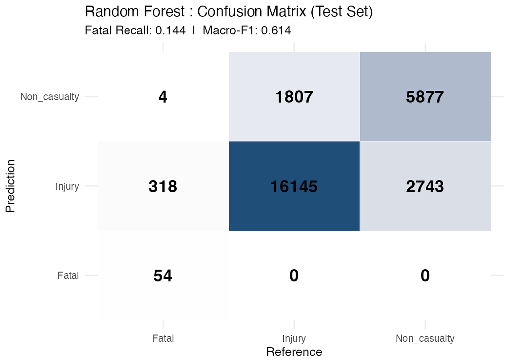

| Metric | Value |
| --- | --- |
| OOB Error Rate | 18.4% |
| Macro-F1 | 0.614 |
| **Fatal Recall** | **0.144** |
| Weighted F1 | 0.813 |
| Kappa | 0.583 |

## Model Fitting: Naive Bayes

**Why Naive Bayes?**

- Probabilistic baseline model
- Suitable for categorical predictors
- Fast to train on large data
- Strong sensitivity to Fatal crashes

| Metric | Value |
| --- | --- |
| Macro-F1 | 0.205 |
| Fatal Recall | 0.856 |
| Weighted F1 | 0.188 |
| Kappa | 0.086 |

High Fatal Recall, but many false alarms.

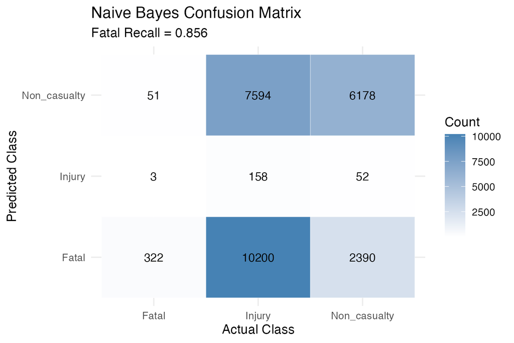

## Model Improvement: Hyperparameter Tuning

[output not shown]

> RF: `tuneRF` identified **mtry = 13** (default = 6) - Macro-F1 +0.020, Fatal Recall +0.037. OOB converges before 75 trees.

## Model Evaluation

[output not shown]